# Exercise 5 data analysis

Pauliina Anttila

5 12 2017

# 5. Dimensionality reduction techniques

**This week we are working with the ‘human’ data. Before analysis, we wrangled the data.**

**You can see data wrangling part here:** https://github.com/pauliinaanttila/IODS-project/blob/master/data/create_human.R.

**Here you can see the original data from the United Nations Development Programme:** http://hdr.undp.org/en/content/human-development-index-hdi.

## Exploring the data:

```r
human <-read.csv(file = "~/Documents/GitHub/IODS-project/data/human.csv", header = TRUE, sep = ",", dec = ".", row.names=1) # reading the data into R
```

```r
dim(human) # exporing the dimensions of the data
```

```
## [1] 155   8
```

```r
str(human) # eploring the structure of the data
```

```
## 'data.frame':    155 obs. of  8 variables:
##  $ Edu2.FM  : num  1.007 0.997 0.983 0.989 0.969 ...
##  $ Labo.FM  : num  0.891 0.819 0.825 0.884 0.829 ...
##  $ Edu.Exp  : num  17.5 20.2 15.8 18.7 17.9 16.5 18.6 16.5 15.9 19.2 ...
##  $ Life.Exp : num  81.6 82.4 83 80.2 81.6 80.9 80.9 79.1 82 81.8 ...
##  $ GNInum   : int  64992 42261 56431 44025 45435 43919 39568 52947 42155 32689 ...
##  $ Mat.Mor  : int  4 6 6 5 6 7 9 28 11 8 ...
##  $ Ado.Birth: num  7.8 12.1 1.9 5.1 6.2 3.8 8.2 31 14.5 25.3 ...
##  $ Parli.F  : num  39.6 30.5 28.5 38 36.9 36.9 19.9 19.4 28.2 31.4 ...
```

**The dataset contains 155 observations of 8 variables. The data combines several indicators from most countries in the world. The variables include the following:**

“Country” = Country name (as row names in the data)

**About health and knowledge:**

“GNI” = Gross National Income per capita

“Life.Exp” = Life expectancy at birth

“Edu.Exp” = Expected years of schooling

“Mat.Mor” = Maternal mortality ratio

“Ado.Birth” = Adolescent birth rate

**Empowerment:**

“Parli.F” = Percetange of female representatives in parliament

“Edu2.F” = Proportion of females with at least secondary education

“Edu2.M” = Proportion of males with at least secondary education

“Labo.F” = Proportion of females in the labour force

“Labo.M” " Proportion of males in the labour force

“Edu2.FM” = Edu2.F / Edu2.M

“Labo.FM” = Labo2.F / Labo2.M

## Overview of the data:

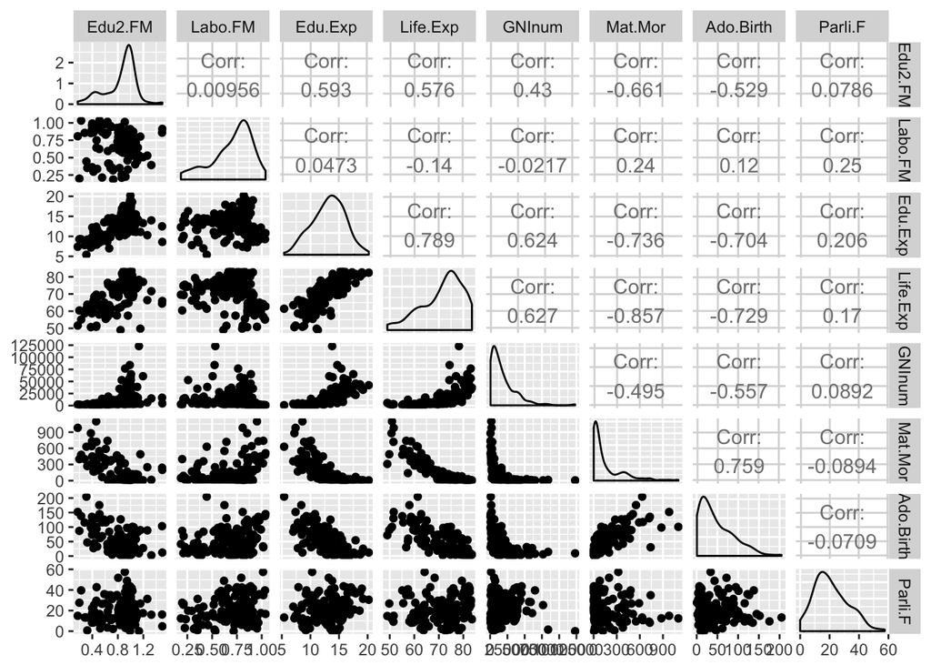

```r
library(GGally)
library(ggplot2)
ggpairs(human, lower = list(combo = wrap("facethist", bins = 20)))
```

**Expected years of schooling seem to been pretty normally distributed. Otherwise the distributions have considerable skewness, a positive one for Gross National Income per capita, maternal mortality ratio, adolescent birth rate and percetange of female representatives in parliament, and a negative one for the rest.**

**It seems that maternal mortality and adolescent births have a positive correlation. Also life expectancy at birth and expected years of schooling have a positive correlation.**

```r
summary(human)
```

```
##     Edu2.FM          Labo.FM          Edu.Exp         Life.Exp
##  Min.   :0.1717   Min.   :0.1857   Min.   : 5.40   Min.   :49.00
##  1st Qu.:0.7264   1st Qu.:0.5984   1st Qu.:11.25   1st Qu.:66.30
##  Median :0.9375   Median :0.7535   Median :13.50   Median :74.20
##  Mean   :0.8529   Mean   :0.7074   Mean   :13.18   Mean   :71.65
##  3rd Qu.:0.9968   3rd Qu.:0.8535   3rd Qu.:15.20   3rd Qu.:77.25
##  Max.   :1.4967   Max.   :1.0380   Max.   :20.20   Max.   :83.50
##      GNInum          Mat.Mor         Ado.Birth         Parli.F
##  Min.   :   581   Min.   :   1.0   Min.   :  0.60   Min.   : 0.00
##  1st Qu.:  4198   1st Qu.:  11.5   1st Qu.: 12.65   1st Qu.:12.40
##  Median : 12040   Median :  49.0   Median : 33.60   Median :19.30
##  Mean   : 17628   Mean   : 149.1   Mean   : 47.16   Mean   :20.91
##  3rd Qu.: 24512   3rd Qu.: 190.0   3rd Qu.: 71.95   3rd Qu.:27.95
##  Max.   :123124   Max.   :1100.0   Max.   :204.80   Max.   :57.50
```

**Life expectancy at birth varies between 49.0 - 83.5 years with the median of 74.2. Expected years of schooling vary between 5.4 - 20.2 years with the median of 13.5. The maternal mortality ratio varies hugely, it ranges from 1.0 - 1100.0.**

## Principal component analysis (PCA):

**Now we are going to perform principal component analysis (PCA) on the not standardized ‘human’ data. It is statistical method used in dimension reduction.**

```r
pca_human <- prcomp(human)
summary(pca_human)
```

```
## Importance of components:
##                              PC1      PC2   PC3   PC4   PC5   PC6    PC7
## Standard deviation     1.854e+04 185.5219 25.19 11.45 3.766 1.566 0.1912
## Proportion of Variance 9.999e-01   0.0001  0.00  0.00 0.000 0.000 0.0000
## Cumulative Proportion  9.999e-01   1.0000  1.00  1.00 1.000 1.000 1.0000
##                           PC8
## Standard deviation     0.1591
## Proportion of Variance 0.0000
## Cumulative Proportion  1.0000
```

**Above in the summary is shown the variability captured by the principal components.**

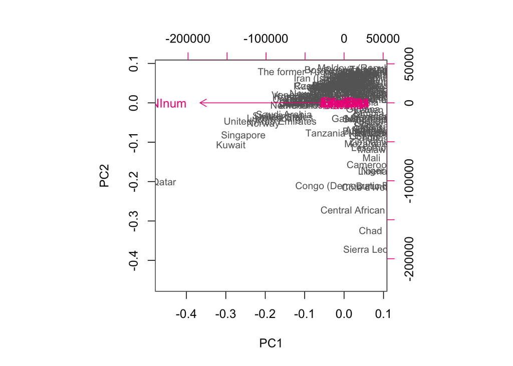

```r
biplot(pca_human, choices = 1:2, cex = c(0.8,1), col = c("grey40", "deeppink2")) # drawing a biplot of the principal component representation and the original variables
```

**A biplot displaying the observations by the first two principal components, along with arrows representing the original variables.**

**Before standardizing the dataset, the variances are so different between the variables that it is difficult to interpret the PCA in a sensible manner. The GNI has more leverage in the unstandardized data because it has a huge variation in values.**

## Standardizing the dataset and performing PCA again:

```r
human_std <- scale(human) # standardizing the dataset
pca_human_std <- prcomp(human_std)
summary(pca_human_std)
```

```
## Importance of components:
##                           PC1    PC2     PC3     PC4     PC5     PC6
## Standard deviation     2.0708 1.1397 0.87505 0.77886 0.66196 0.53631
## Proportion of Variance 0.5361 0.1624 0.09571 0.07583 0.05477 0.03595
## Cumulative Proportion  0.5361 0.6984 0.79413 0.86996 0.92473 0.96069
##                            PC7     PC8
## Standard deviation     0.45900 0.32224
## Proportion of Variance 0.02634 0.01298
## Cumulative Proportion  0.98702 1.00000
```

**After standardization, the variances of the variables are more alike.**

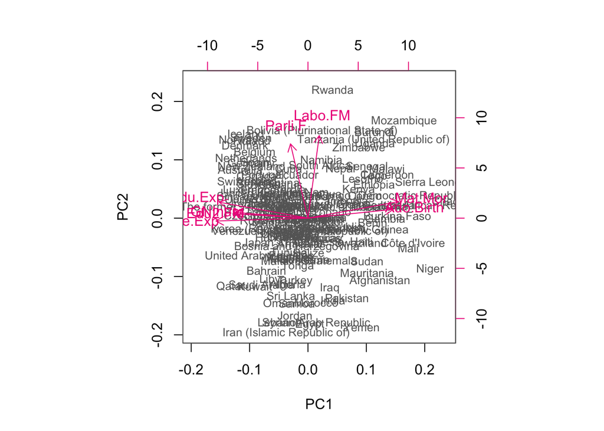

```r
biplot(pca_human_std, choices = 1:2, cex = c(0.8,1), col = c("grey40", "deeppink2"))
```

**Now we can truly see the connections between variables.**

**It seems that maternal mortality ratio and adolescent birth rate have a high positive correlation (small angle between the arrows).**

**Life expectancy at birth, expected years of schooling and GNI are positively correlated.**

## Interpretation of the first two principal component dimensions:

**Factors contributing to PC1 are maternal mortality ratio and adolescent birth rate (arrows to the same direction).**

**Variables contributing to PC2 are Parli.F and Labo.FM.**

## Working with ‘tea’ dataset:

```r
library(FactoMineR)
data(tea) # loading the 'tea' dataset from the package FactoMineR
dim(tea)
```

```
## [1] 300  36
```

```r
str(tea)
```

```
## 'data.frame':    300 obs. of  36 variables:
##  $ breakfast       : Factor w/ 2 levels "breakfast","Not.breakfast": 1 1 2 2 1 2 1 2 1 1 ...
##  $ tea.time        : Factor w/ 2 levels "Not.tea time",..: 1 1 2 1 1 1 2 2 2 1 ...
##  $ evening         : Factor w/ 2 levels "evening","Not.evening": 2 2 1 2 1 2 2 1 2 1 ...
##  $ lunch           : Factor w/ 2 levels "lunch","Not.lunch": 2 2 2 2 2 2 2 2 2 2 ...
##  $ dinner          : Factor w/ 2 levels "dinner","Not.dinner": 2 2 1 1 2 1 2 2 2 2 ...
##  $ always          : Factor w/ 2 levels "always","Not.always": 2 2 2 2 1 2 2 2 2 2 ...
##  $ home            : Factor w/ 2 levels "home","Not.home": 1 1 1 1 1 1 1 1 1 1 ...
##  $ work            : Factor w/ 2 levels "Not.work","work": 1 1 2 1 1 1 1 1 1 1 ...
##  $ tearoom         : Factor w/ 2 levels "Not.tearoom",..: 1 1 1 1 1 1 1 1 1 2 ...
##  $ friends         : Factor w/ 2 levels "friends","Not.friends": 2 2 1 2 2 2 1 2 2 2 ...
##  $ resto           : Factor w/ 2 levels "Not.resto","resto": 1 1 2 1 1 1 1 1 1 1 ...
##  $ pub             : Factor w/ 2 levels "Not.pub","pub": 1 1 1 1 1 1 1 1 1 1 ...
##  $ Tea             : Factor w/ 3 levels "black","Earl Grey",..: 1 1 2 2 2 2 2 1 2 1 ...
##  $ How             : Factor w/ 4 levels "alone","lemon",..: 1 3 1 1 1 1 1 3 3 1 ...
```

[output cut: 22 more lines]

```r
colnames(tea)
```

```
##  [1] "breakfast"        "tea.time"         "evening"
##  [4] "lunch"            "dinner"           "always"
##  [7] "home"             "work"             "tearoom"
## [10] "friends"          "resto"            "pub"
## [13] "Tea"              "How"              "sugar"
## [16] "how"              "where"            "price"
## [19] "age"              "sex"              "SPC"
## [22] "Sport"            "age_Q"            "frequency"
## [25] "escape.exoticism" "spirituality"     "healthy"
## [28] "diuretic"         "friendliness"     "iron.absorption"
## [31] "feminine"         "sophisticated"    "slimming"
## [34] "exciting"         "relaxing"         "effect.on.health"
```

**The ‘tea’ dataset has 300 observations of 36 variables concerning tea consumption (for example if tea is consumed during breakfast, lunch, dinner etc.).**

**Let’s create a bit smaller dataset:**

```r
keep_columns <- c("Tea", "How", "how", "sugar", "where", "resto", "pub")
tea_selected <- tea[, keep_columns] # creating a smaller dataset with the selected columns
```

```r
dim(tea_selected)
```

```
## [1] 300   7
```

**The new ‘tea_selected’ dataset contains 300 observations of 7 variables. Summary of the variables is seen below:**

```r
summary(tea_selected)
```

```
##         Tea         How                      how           sugar
##  black    : 74   alone:195   tea bag           :170   No.sugar:155
##  Earl Grey:193   lemon: 33   tea bag+unpackaged: 94   sugar   :145
##  green    : 33   milk : 63   unpackaged        : 36
##                  other:  9
##                   where           resto          pub
##  chain store         :192   Not.resto:221   Not.pub:237
##  chain store+tea shop: 78   resto    : 79   pub    : 63
##  tea shop            : 30
##
```

```r
library(dplyr)
```

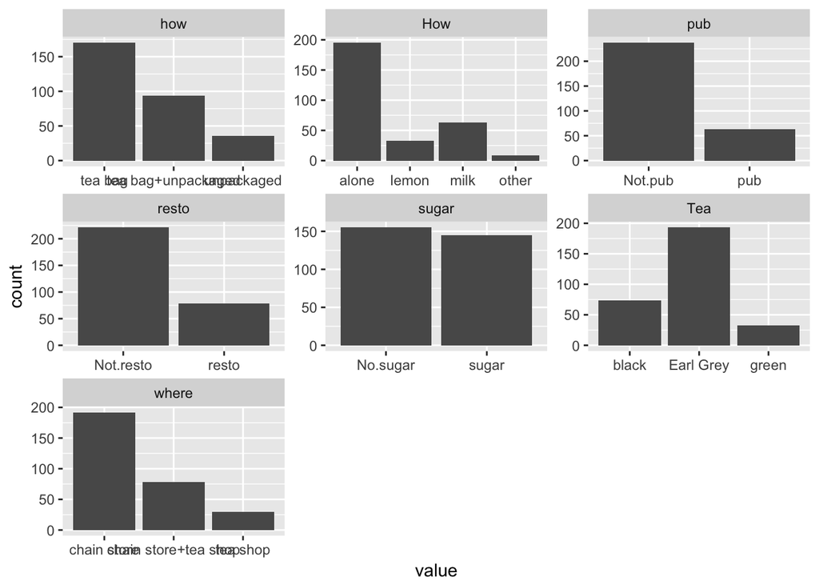

```r
library(tidyr)
gather(tea_selected) %>% ggplot(aes(value)) + facet_wrap("key", scales = "free") + geom_bar()
```

### Multiple correspondence analysis with the ‘tea’ dataset:

```r
mca <- MCA(tea_selected, graph = FALSE)
summary(mca)
```

```
##
## Call:
## MCA(X = tea_selected, graph = FALSE)
##
##
## Eigenvalues
##                        Dim.1   Dim.2   Dim.3   Dim.4   Dim.5   Dim.6
## Variance               0.258   0.240   0.192   0.164   0.156   0.133
## % of var.             15.038  14.027  11.184   9.591   9.105   7.767
## Cumulative % of var.  15.038  29.065  40.250  49.841  58.946  66.713
##                        Dim.7   Dim.8   Dim.9  Dim.10  Dim.11  Dim.12
## Variance               0.127   0.118   0.102   0.098   0.074   0.052
## % of var.              7.409   6.879   5.969   5.713   4.300   3.018
## Cumulative % of var.  74.122  81.000  86.969  92.682  96.982 100.000
##
## Individuals (the 10 first)
##                       Dim.1    ctr   cos2    Dim.2    ctr   cos2    Dim.3
## 1                  | -0.355  0.163  0.133 | -0.288  0.115  0.088 |  0.237
## 2                  | -0.244  0.077  0.043 | -0.260  0.093  0.049 |  0.718
## 3                  |  0.049  0.003  0.003 | -0.382  0.203  0.159 |  0.195
## 4                  | -0.359  0.167  0.220 | -0.479  0.318  0.391 | -0.276
## 5                  | -0.342  0.152  0.206 | -0.344  0.164  0.208 |  0.111
## 6                  | -0.342  0.152  0.206 | -0.344  0.164  0.208 |  0.111
## 7                  | -0.342  0.152  0.206 | -0.344  0.164  0.208 |  0.111
## 8                  | -0.244  0.077  0.043 | -0.260  0.093  0.049 |  0.718
## 9                  |  0.474  0.290  0.144 |  0.111  0.017  0.008 |  0.186
## 10                 |  0.384  0.191  0.101 |  0.410  0.233  0.116 |  0.604
##                       ctr   cos2
## 1                   0.097  0.059 |
## 2                   0.896  0.372 |
## 3                   0.066  0.041 |
## 4                   0.132  0.129 |
## 5                   0.022  0.022 |
## 6                   0.022  0.022 |
## 7                   0.022  0.022 |
## 8                   0.896  0.372 |
## 9                   0.060  0.022 |
## 10                  0.634  0.250 |
##
## Categories (the 10 first)
```

[output cut: 17 more lines]

```
## milk                 0.038  -3.383 |   0.333   1.736   0.029   2.969 |
## other                0.001   0.563 |   1.906   8.116   0.112   5.795 |
## tea bag              0.475 -11.913 |  -0.017   0.012   0.000  -0.327 |
## tea bag+unpackaged   0.052   3.947 |   0.090   0.190   0.004   1.053 |
## unpackaged           0.525  12.533 |  -0.157   0.221   0.003  -1.005 |
##
## Categorical variables (eta2)
##                      Dim.1 Dim.2 Dim.3
## Tea                | 0.186 0.105 0.456 |
## How                | 0.218 0.091 0.353 |
## how                | 0.317 0.704 0.006 |
## sugar              | 0.001 0.054 0.351 |
## where              | 0.533 0.714 0.029 |
## resto              | 0.375 0.003 0.013 |
## pub                | 0.175 0.012 0.134 |
```

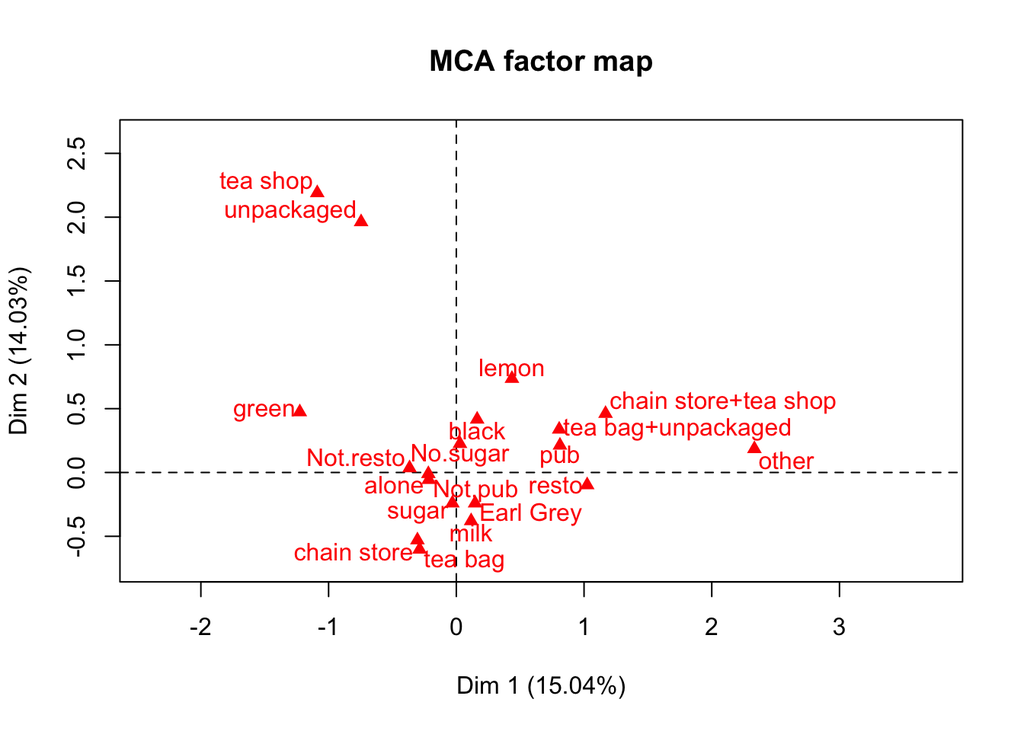

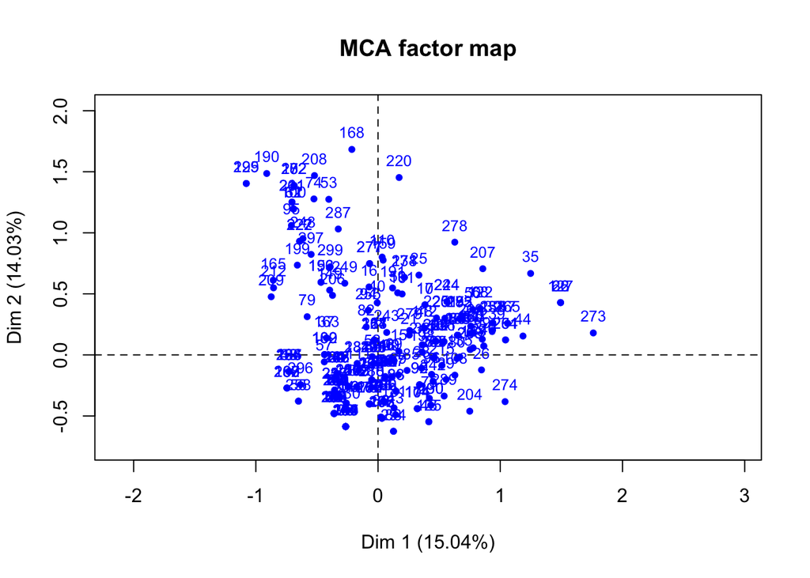

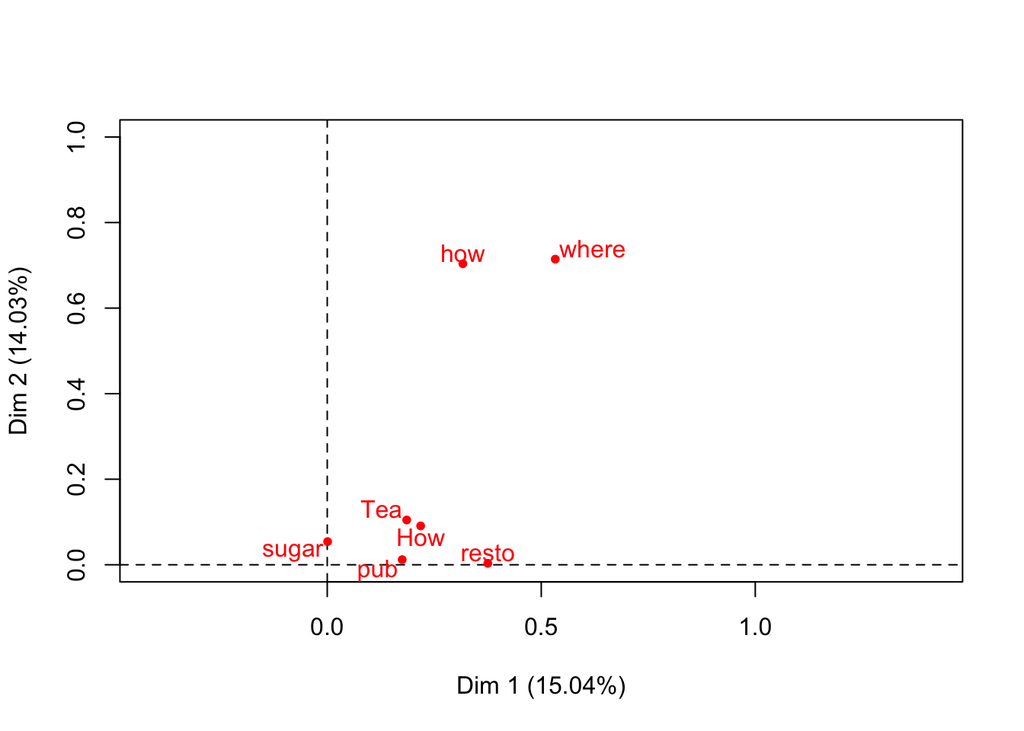

```r
mca <- MCA(tea_selected, graph = TRUE)
```

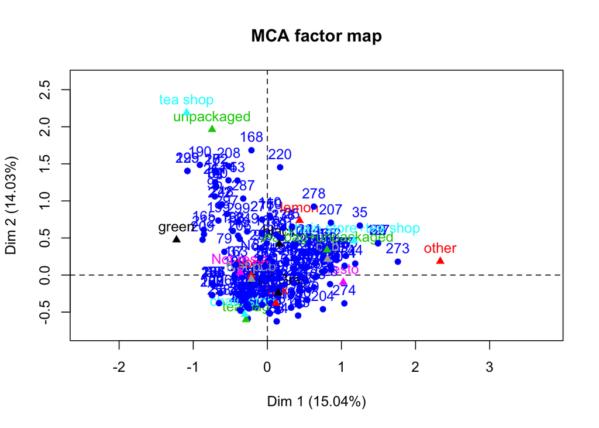

```r
plot(mca, invisible=c(), habillage = "quali")
```